# BIKE USAGE ANALYSIS PROJECT USING PYTHON - INDIVIDUAL ASSIGNMENT

## 1. Introduction

This analysis explores patterns in bike usage from the perspectives of various rider groups. Key factors such as time of day, day of the week, weather, seasons, holidays, and rental behaviors are examined to understand what drives bike rental decisions. The goal is to identify the most favorable conditions that influence higher ridership and provide insight into user motivations. A survey by Fitch, Carlen, and Handy (2022) highlights that recognizing the environments in which riders feel most comfortable is critical to improving engagement. These insights are framed to support decision-making in a results-driven business context, especially for non-technical stakeholders.

## 2. Insights

### Insight 1: Afternoon and Evening Hours Drive Peak Bike Rentals

The data reveals that bike rentals significantly increase during the late afternoon and early evening, particularly between 4 PM and 8 PM. This pattern suggests that many users are utilizing bikes for commuting purposes, aligning with typical workday end times. Such usage indicates a preference for biking as a convenient and efficient mode of transportation during rush hours. Also bike commuting, such as cycling to work, is positively associated with better cardiovascular health, lower obesity rates, and improved physical fitness among employed adults (Leung, A. Scheer, J. & Wennberg, H. (2025))

Thus, to capitalize on this trend, the company should ensure increased bike availability during these peak hours, possibly by reallocating resources or implementing dynamic pricing strategies. Additionally, promoting subscription models or loyalty programs targeted at daily commuters could enhance user retention and satisfaction.

### Insight 2: Favorable Weather Conditions Boost Bike Rentals

Analysis indicates that bike rentals surge during mild weather conditions, particularly in spring, summer, and autumn. Optimal temperatures, low humidity, and clear skies encourage more individuals to choose biking as their mode of transport. Conversely, adverse weather conditions like rain, snow, or extreme temperatures deter users, leading to decreased rentals (Fitch, Carlen, and Handy (2022). Thus, the company should focus marketing efforts during favorable weather periods, perhaps by offering promotions or organizing events to attract users. During less favorable conditions, providing incentives or highlighting safety measures can help maintain user engagement. Additionally, integrating weather forecasts into operational planning can aid in resource allocation and demand prediction.

## 3. Purpose of the three coding cells below

The fundamental purpose of the codes below is that, they prepare the environment for analyzing the bike rental dataset by importing key libraries, reading the data into Python, and suppressing unnecessary user warnings to keep the output clean. They also include a help command to assist users in understanding how to correctly use the pd.read_excel function for loading Excel files into Python.

```python
# Suppressing user warnings
import warnings # warnings
warnings.simplefilter(action = 'ignore', category = UserWarning)
```

```python
# Provide help detail to run correct code
help(pd.read_excel)
```

```python
# Importing necessary libraries and loading the bike rental dataset into Python for analysis.

import pandas as pd # data science essentials
import matplotlib.pyplot as plt # NEW: data visualization essentials
import seaborn as sns # NEW: enhanced data visualization

# Storing path to bike data set
file = "bikes_data.xlsx"

# Reading the file into Python through pandas
bikes = pd.read_excel(io = file)
```

## 4. Data cleaning and filtering for visualiations

This is a summary discription on the two coding cells and its output below.

```python
## Loads and filters selected bike data columns while converting types to strings for easier weekly weather-based ride preference analysis.

# Check for missing values and data types
df.isnull().sum()
df.describe()

# converting data types with a dictionary
data_types = {"Months" : str,
              "Day of Week" : str,
              "Hours" : str,
              "Temperature" : str,}


# instantiating the dataset as an object
bikes_df = pd.read_excel(io         = file ,
                         sheet_name = 0 ,
                         header     = 0 ,
                         dtype      = data_types,   # applying new data types
                         usecols    = ['Month', 'Temperature', 'RENTALS'] )


# checking results
filtered_df.head()
```

[output not shown]

```python
## Preparing weather and rental data as categorical variables to analyze bike usage patterns across different conditions.

# converting data types with a dictionary
data_types = {"Temperature": str,
              "Humidity": str,
             "Rainfall": str,
             "Snowfall": str,
             "RENTALS": str}


# reading the file into Python through pandas
bikes_df = pd.read_excel(io     = file,
                     sheet_name = 0,
                     header     = 0,
                     dtype      = data_types)



# outputting the first 5 rows of the dataset
bikes_df.head (n = 6)
```

|  | ID | Month | Day of Week | Hour | Temperature | Humidity | Wind Speed | Visibility | Dew Point Temperature | UV Index | Rainfall | Snowfall | Season | Holiday | RENTALS |
| --- | --- | --- | --- | --- | --- | --- | --- | --- | --- | --- | --- | --- | --- | --- | --- |
| 0 | 1 | Jan | Sunday | 0 | -3.2 | 40 | 0.5 | 1358 | -14.9 | 0.00 | 0 | 0 | Winter | Yes | 221 |
| 1 | 2 | Jan | Sunday | 13 | 2.4 | 22 | 2.3 | 1921 | -17.2 | 1.10 | 0 | 0 | Winter | Yes | 268 |
| 2 | 3 | Jan | Sunday | 16 | 3 | 28 | 2.5 | 1864 | -13.7 | 0.51 | 0 | 0 | Winter | Yes | 335 |
| 3 | 4 | Jan | Sunday | 17 | 1.8 | 33 | 3.3 | 1913 | -12.8 | 0.18 | 0 | 0 | Winter | Yes | 299 |
| 4 | 5 | Jan | Sunday | 20 | -0.3 | 40 | 1.2 | 1936 | -12.2 | 0.00 | 0 | 0 | Winter | Yes | 225 |
| 5 | 6 | Jan | Monday | 10 | -1.4 | 50 | 1.9 | 1355 | -10.5 | 0.38 | 0 | 0 | Winter | No | 221 |

## 5. Visualizations and analysis on bikes dataset

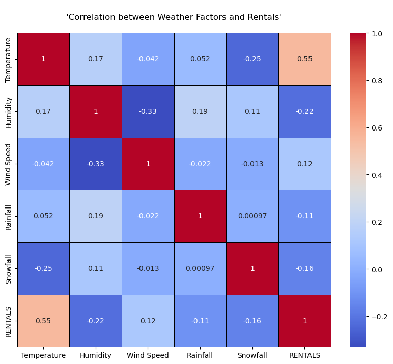

```python
## Insight One: Visualizing How Weather Factors Correlate with Bike Rental Volumes

# Temperature and humidity affect rental volumes.

# specifying plot size (making it bigger)
fig, ax = plt.subplots( figsize = (10 , 8) )


# developing a spicy heatmap
sns.heatmap(df[['Temperature', 'Humidity', 'Wind Speed', 'Rainfall', 'Snowfall', 'RENTALS']].corr(),
            cmap       = 'coolwarm',
            square     = True ,
            annot      = True ,
            linecolor  = 'black',
            linewidths = 0.5 )


# title and displaying the plot
plt.title(label = """
'Correlation between Weather Factors and Rentals'
""")

# showing the finished product
plt.show(block = True)
```

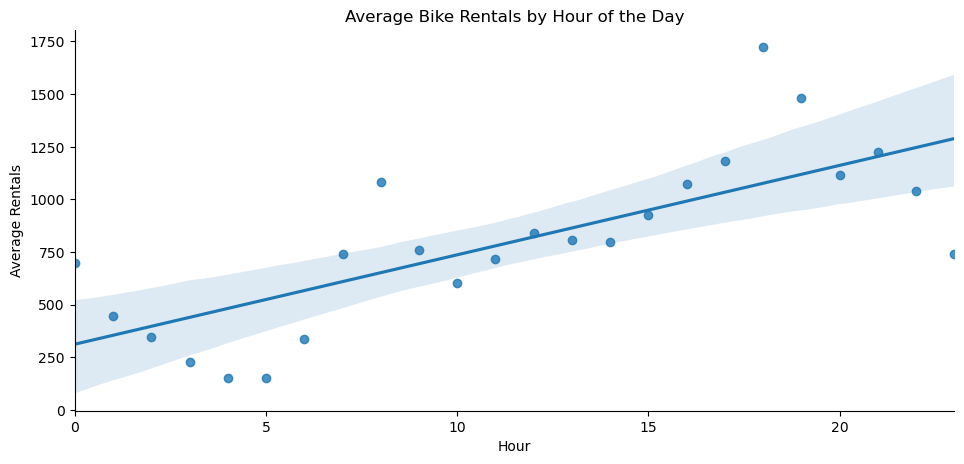

```python
## Insight 2: Bike rentals peak during specific hours, showing clear daily time preferences for riding

# Calculating average rentals by hour
hourly_rentals = df.groupby('Hour')['RENTALS'].mean().reset_index()

# Create regression scatterplot with seaborn
plot  = sns.lmplot(
    x = 'Hour',              # x-axis: Hour of the day
    y = 'RENTALS',           # y-axis: Average Rentals
    data = hourly_rentals,   # Use the hourly average data
    scatter = True,         # Show scatter points
    fit_reg = True,         # Add regression line
    aspect = 2              # Aspect ratio
)

# Apply labels using plot.ax, not plt directly
plot.ax.set_title ('Average Bike Rentals by Hour of the Day')
plot.set_axis_labels ('Hour', 'Average Rentals')
plot.set(xlim = (0, 23))  # Set correct x-axis limits for hours 0–23

# Layout adjustment and display
plt.tight_layout (pad = 2.0)
plt.show()
```

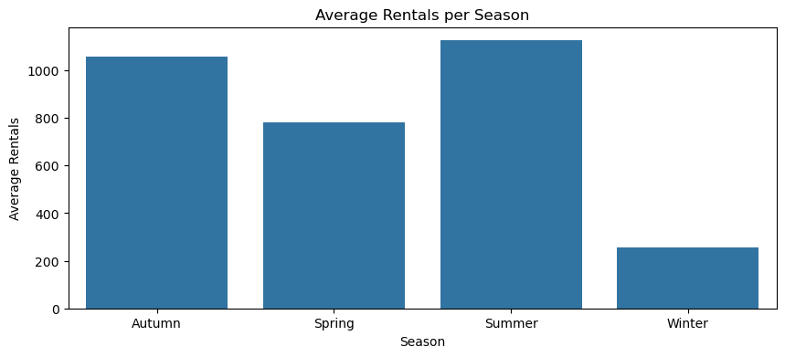

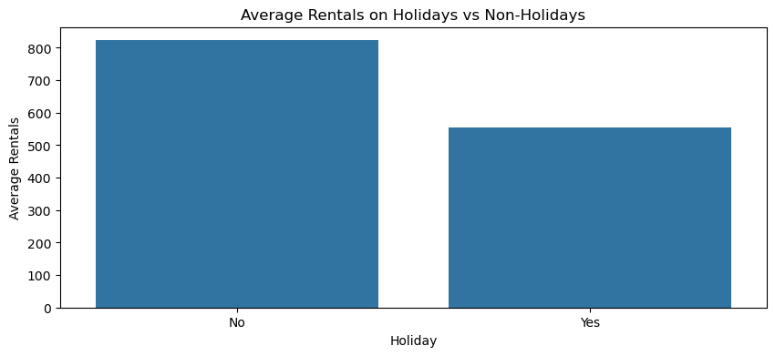

```python
## Insight Three: Seasonal Trends and Holiday Impact Significantly Influence Average Bike Rentals

# Average rentals by season and holiday
seasonal_rentals = df.groupby('Season')['RENTALS'].mean().reset_index()
holiday_rentals = df.groupby('Holiday')['RENTALS'].mean().reset_index()

# Season chart
plt.figure(figsize = (10,4))
sns.barplot(x = 'Season', y ='RENTALS', data = seasonal_rentals)
plt.title('Average Rentals per Season')
plt.xlabel('Season')
plt.ylabel('Average Rentals')
plt.show()

# Holiday chart
plt.figure(figsize = (10,4))
sns.barplot(x = 'Holiday', y = 'RENTALS', data = holiday_rentals)
plt.title('Average Rentals on Holidays vs Non-Holidays')
plt.xlabel('Holiday')
plt.ylabel('Average Rentals')
plt.show()
```

### 5.3. Analysis:

Bike rentals are highest in summer and autumn, indicating these are peak demand seasons due to favorable weather. Winter sees the lowest rentals, likely because colder temperatures reduce outdoor activity. The data also shows that rentals drop on holidays compared to regular days. This suggests that people may prefer staying indoors or using other transportation on holidays. Overall, seasonality and holidays significantly influence rental behavior.

## 6. Strategic recommendations:

Based on the visuals, bike rentals peak during summer and autumn, suggesting businesses should prioritize advertising, promotions, and bike availability in these seasons to meet demand. In contrast, rentals drop significantly in winter, making it an ideal time to scale down the fleet or focus on maintenance and off-season planning. Rentals are notably higher on non-holidays, so offering special promotions or discounts on holidays could help boost usage. Since the afternoon and early evening are peak hours, bikes should be fully restocked by midday to avoid lost opportunities. Aligning marketing, operations, and inventory with these patterns can enhance customer satisfaction and improve profitability.

## 7. Conclusion

Overall, the findings reveal clear patterns in how people use bikes depending on the time of year, weather, and day type. Warm and dry conditions tend to attract more riders, while colder and wet periods see a decline in activity. People are more likely to ride during certain times of day, especially in the late afternoon when they’re likely free from work or school. The drop in usage during holidays hints that different activities may take priority, or that fewer people are out and about. These patterns can guide better planning, promotions, and services that match when and how people actually want to ride.

## 8. References

Leung, A. Scheer, J. & Wennberg, H. (2025). Active commuting and its association with cardiovascular health, obesity, and physical fitness among employed adults: A cross-sectional study. BMC Public Health, 25(1), Article 22634. https://doi.org/10.1186/s12889-025-22634-2

OpenAI. (2025). ChatGPT (May 21 version). What codes are required to build a bar-chart. [Large language model]. https://chat.openai.com/